# Chapter 3 Grammar of Graphics

Nils Indreiten

06/03/2022

The dataset contains measures that are relevant to answer economic questions.

## Aesthetics:

In the example below a multivariate graphic is created:

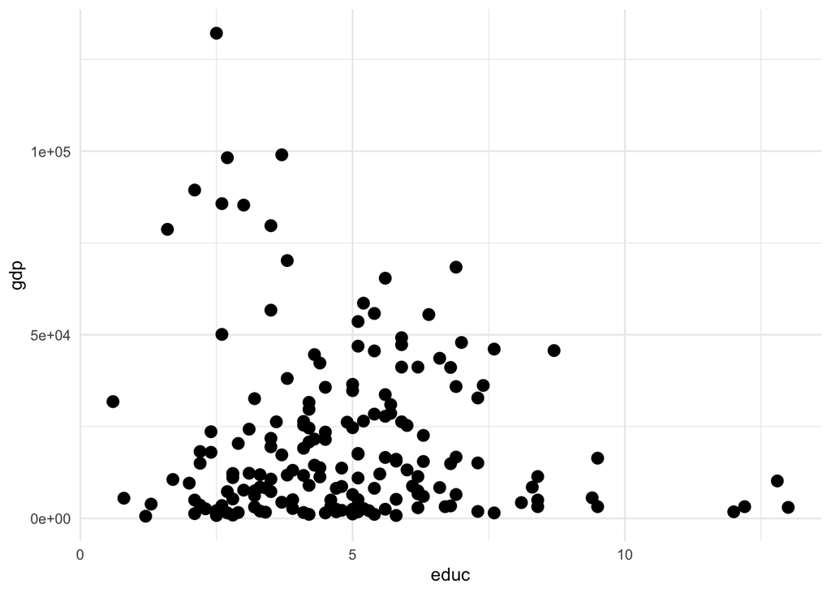

```r
CIACountries %>% ggplot(aes(y=gdp,x=educ))+geom_point(size=3)
```

Additional aesthetics can be created, for example mapping the color of each dot to the categorical net_useds variable:

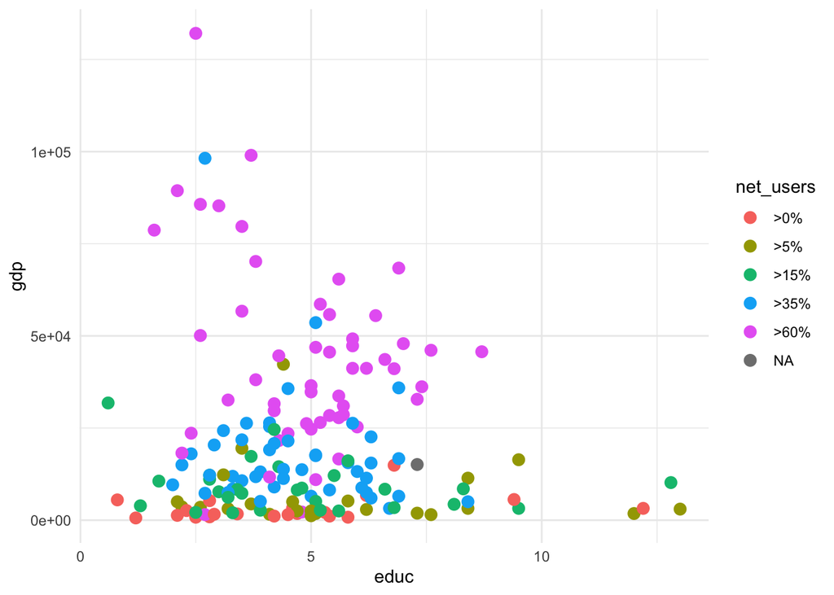

```r
CIACountries %>% ggplot(aes(y=gdp,x=educ, color= net_users))+geom_point(size=3)
```

We can even change the nature of the glyphs, such as text instead of points:

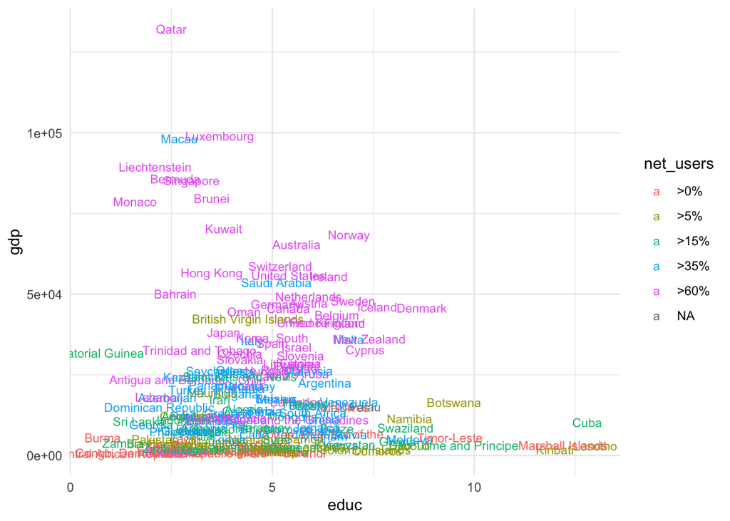

```r
CIACountries %>% ggplot(aes(y=gdp,x=educ, color=net_users))+geom_text(aes(label=country,color=net_users), size=3)
```

We can also employ multiple aesthetics simultaneously:

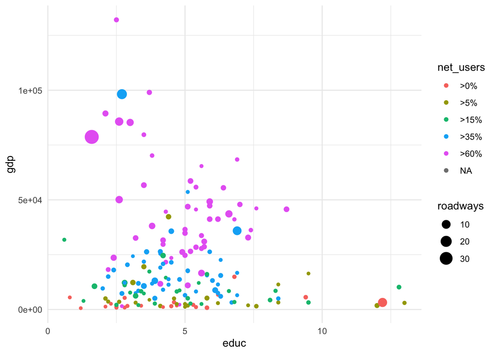

```r
g <- ggplot(data = CIACountries, aes(y = gdp, x = educ))
g + geom_point(aes(color = net_users, size = roadways))
```

## Scales

It is difficult to discern differences in GDP due to its right skewed distribution and the linear scale. We can change this using logarithmic scale on the vertical axes to make it more readable. However this makes the plot more complex to interpret, the only difference in the code is the addition of coord_trans():

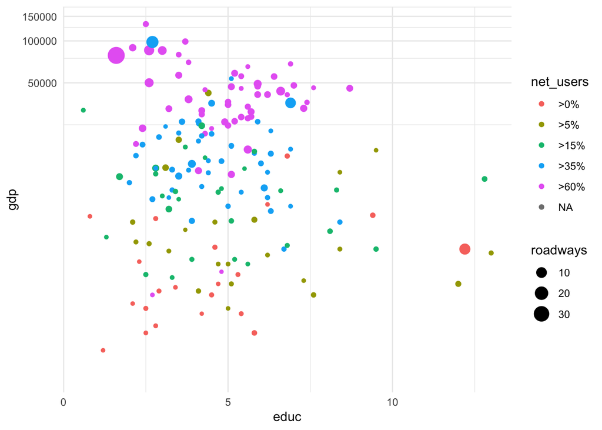

```r
g+geom_point(aes(color=net_users, size=roadways))+
  coord_trans(y="log10")
```

Scales can also be manipulated in ggplot2. For instance instead of using coord_trans() we could have used scale_y_continuous():

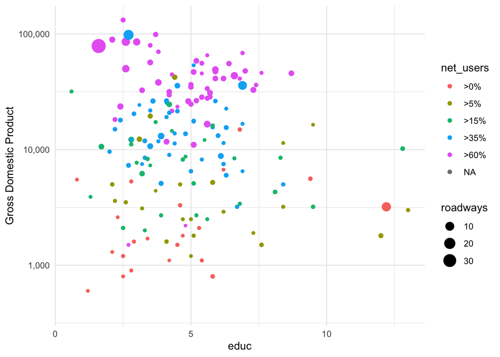

```r
g +
  geom_point(aes(color = net_users, size = roadways)) +
  scale_y_continuous(
    name = "Gross Domestic Product",
    trans = "log10",
    labels = scales::comma
  )
```

## Facets

Using multiple aesthetics can e confusing. Facets provide multiple side-by-side graphs used to display levels of a categorical variable. :

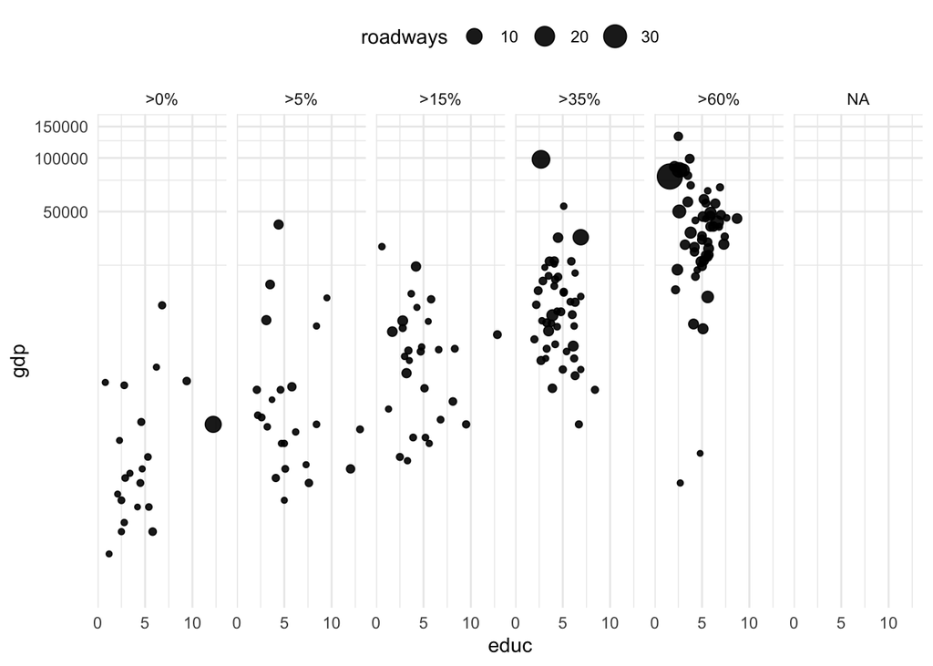

```r
g +
  geom_point(alpha = 0.9, aes(size = roadways)) +
  coord_trans(y = "log10") +
  facet_wrap(~net_users, nrow = 1) +
  theme(legend.position = "top")
```

## Layers

One occassion, data from more than one data table are graphed together for example the MediCareCharder and MedicareProviders data tables provide information about the average cost of each medical procedure in each state. If you live in NJ you might wonder how providers in your state charge for different medical procedures. However, you will certainly want to understand those averages in the context of the averages accross all states. In the MedicareCharges table, each row represents a different medical procedure (drg) with its associated average cost in each state:

```r
ChargesNJ <- MedicareCharges %>%
  filter(stateProvider == "NJ")
```

We can visualise this information using geom_col():

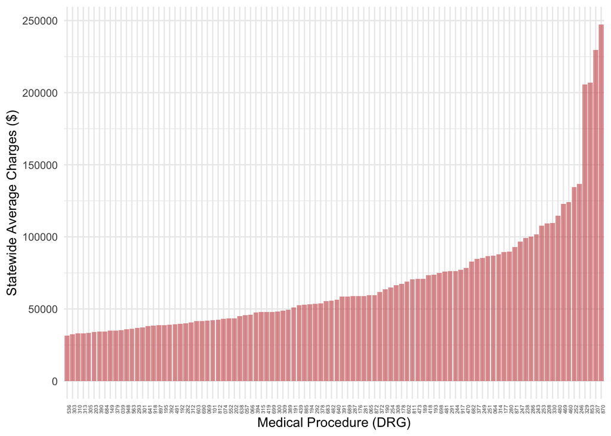

```r
p <- ChargesNJ %>%
  ggplot(aes(reorder(drg, mean_charge), y= mean_charge))+
  geom_col(fill="indianred3", alpha=0.6)+
  ylab("Statewide Average Charges ($)")+
  xlab("Medical Procedure (DRG)")+
  theme(axis.text.x = element_text(angle = 90,hjust = 1,size = rel(0.5)))
p
```

How do these charges compare to New Jersey? The two data tabels, one for NJ and one for the whole country, can be plotted with different glyph types: bars for NJ and dots for the states accross the country:

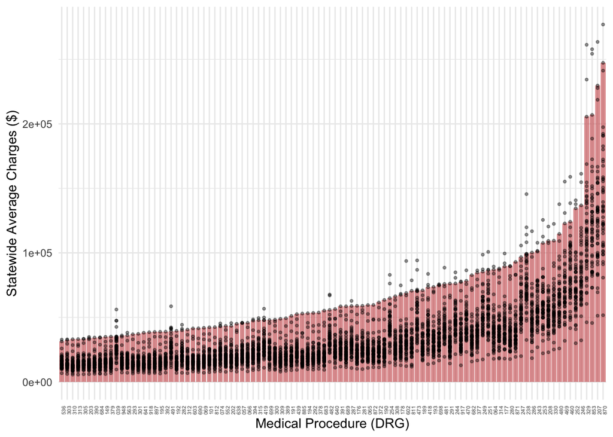

```r
p+geom_point(data = MedicareCharges,size=0.8,alpha=0.4)
```

# Canonical data graphics in R

## Univariate displays:

Thes types of graphs are used for seeking to understand how a single variable is distributed. If numeric then commonly summarised using a histogram or density plot. We can dilay iether plot for the math variable in the SAT_2010 data frame by binding the math variable to the x aesthetic:

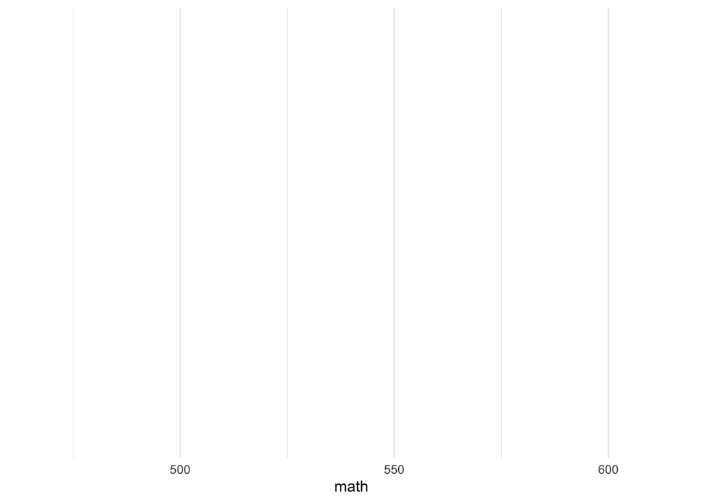

```r
g <- ggplot(SAT_2010, aes(x=math))
g
```

A histogram:

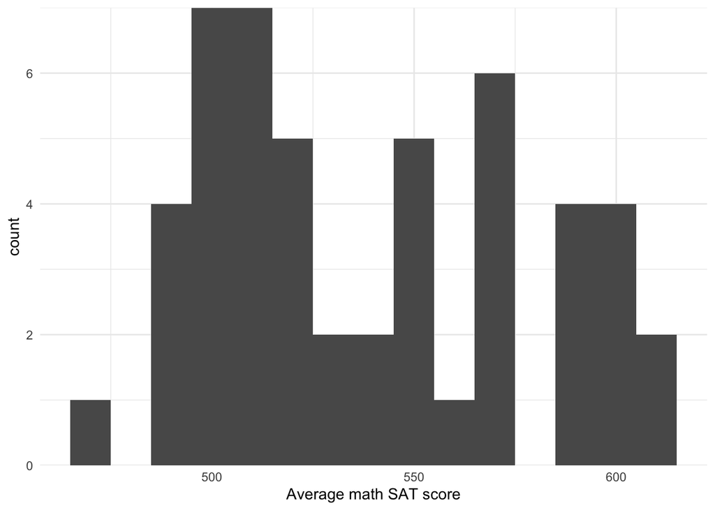

```r
g+geom_histogram(binwidth = 10)+labs(x="Average math SAT score")+scale_y_continuous(expand = c(0,0))
```

Binwidths determine the bins in the histogram, no right answer here. A geom density plot:

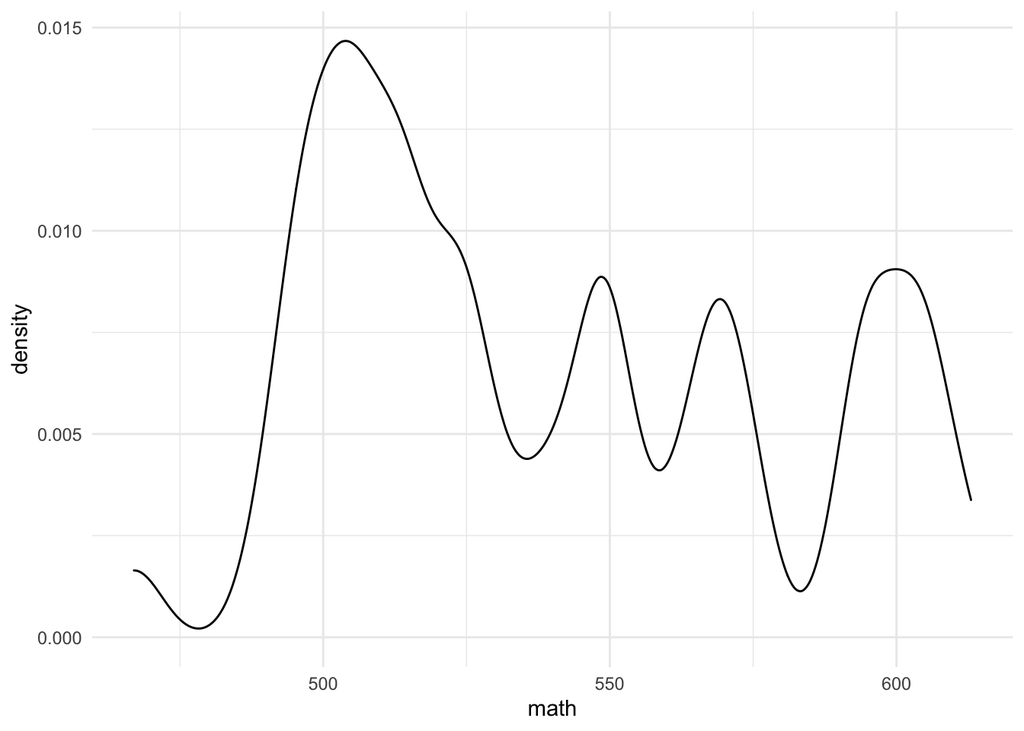

```r
g+geom_density(adjust= 0.3)
```

Adjust arguement is used to modify thebandwidth being used by the lernel smoother. If the variable is categorical it doesnt make sense to think about the values as having a continous density. Instead use bar graph:

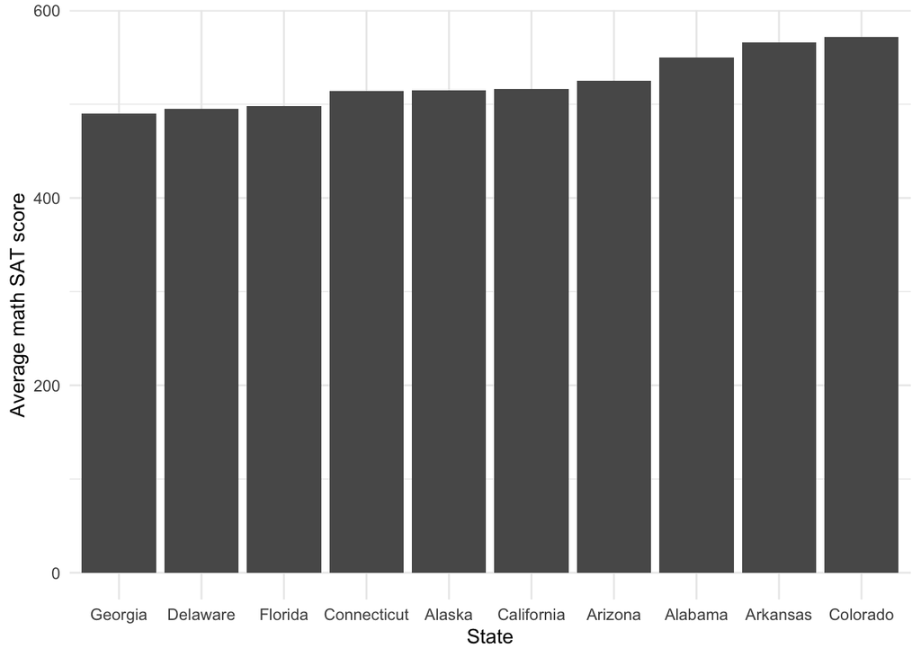

```r
head(SAT_2010, 10) %>%
  ggplot(aes(x=reorder(state,math), y= math))+
  geom_col()+
  labs(x="State", y="Average math SAT score")
```

A stacked bar plot is also effective, it is a combination of coord_flip() and geom_bar():

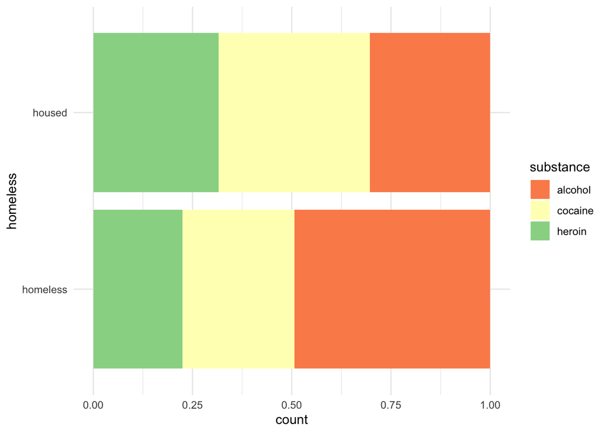

```r
mosaicData::HELPrct %>%
  ggplot(aes(homeless))+
  geom_bar(aes(fill=substance), position = "fill")+
  scale_fill_brewer(palette = "Spectral")+
  coord_flip()
```

## Multivariate displays

Used to display relationship between more than one varible:

```r
g <- ggplot(
  data = SAT_2010,
  aes(x = expenditure, y = math)
) +
  geom_point()
g <- g +
  geom_smooth(method = "lm", se = FALSE) +
  xlab("Average expenditure per student ($1000)") +
  ylab("Average score on math SAT")
```

create a new categorical variable to calculate the SAT_rates:

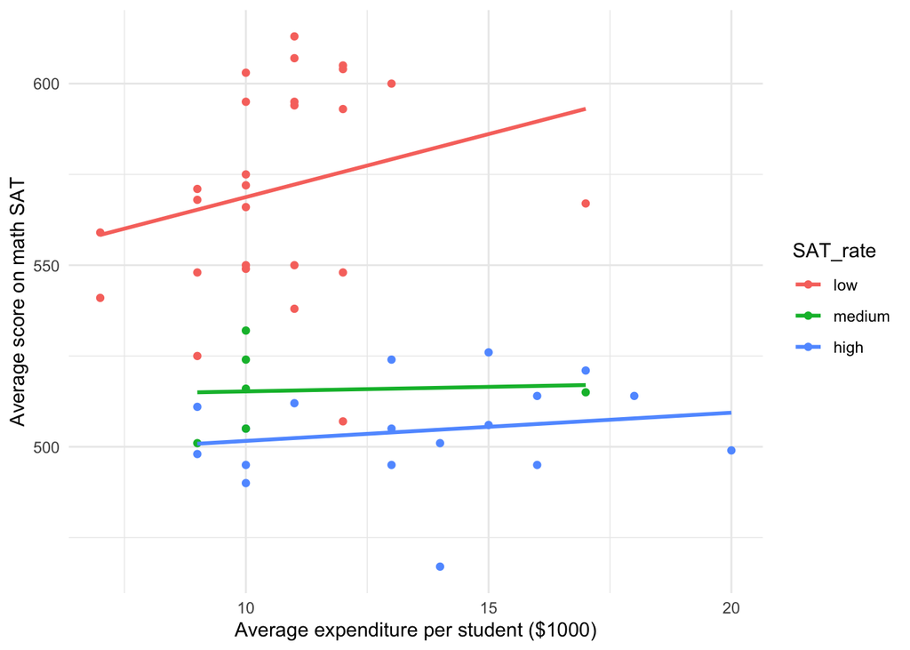

```r
SAT_2010 <- SAT_2010 %>%
  mutate(SAT_rate = cut(
    sat_pct,
    breaks = c(0,30,60,100),
    labels = c("low","medium","high")
  )
)

g <- g%+% SAT_2010
g+aes(color=SAT_rate)
```

The NHANES data table provides medical, behavioural, and morphometric measuremnts of individuals. The plot below shows the relationship between height and age. Some more wrangling is necessary to ensure spatial relationship of the lnes matches the ordering of the legend labels. We can achieve this with fct_relevel():

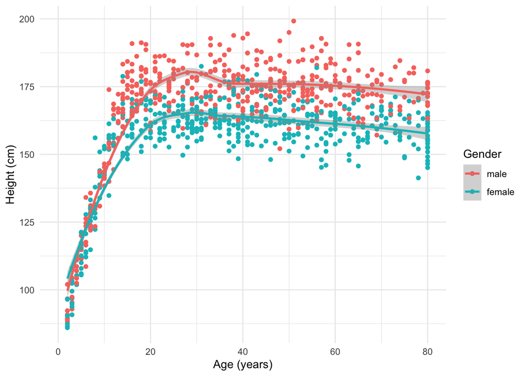

```r
pacman::p_load(NHANES)
slice_sample(NHANES, n=1000) %>%
ggplot(aes(Age, Height, color = fct_relevel(Gender,"male")))+
  geom_point()+
  geom_smooth()+
  xlab("Age (years)")+
  ylab("Height (cm)")+
  labs(color = "Gender")+
  theme_minimal()
```

Some scatterplots have special meanings. A time series is a scatterplot over time.

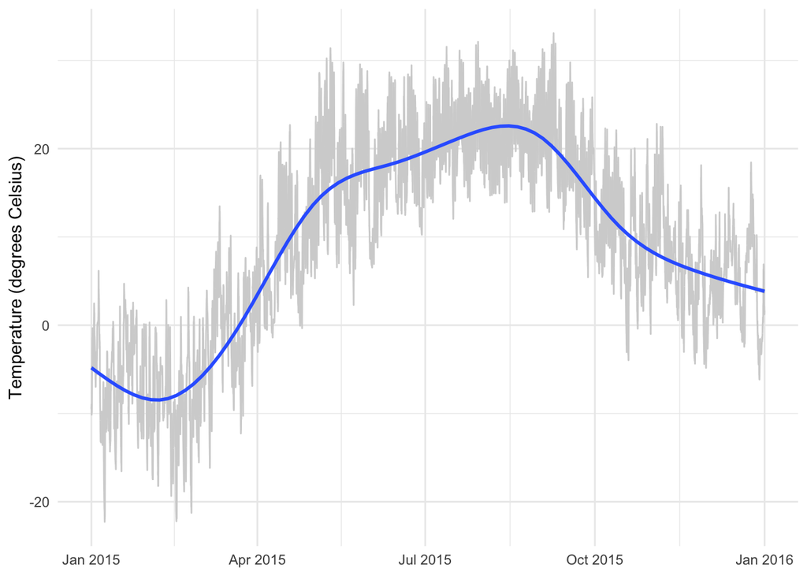

```r
pacman::p_load(macleish)
whately_2015 %>% ggplot(aes(when, temperature))+
  geom_line(color="lightgray")+
  geom_smooth()+
  xlab(NULL)+
  ylab("Temperature (degrees Celsius)")
```

A box and whisker plot may be a better way to visualise a numerical response variable against a categorical explanatory variables:

```r
whately_2015 %>%
  mutate(month= as.factor(lubridate::month(when, label = TRUE))) %>%
  group_by(month) %>%
  skim(temperature) %>%
  select(-na)
```

**Variable type: numeric**

| var | month | n | mean | sd | p0 | p25 | p50 | p75 | p100 |
| --- | --- | --- | --- | --- | --- | --- | --- | --- | --- |
| temperature | Jan | 4464 | -6.37 | 5.14 | -22.28 | -10.26 | -6.25 | -2.35 | 6.16 |
| temperature | Feb | 4032 | -9.26 | 5.11 | -22.21 | -12.26 | -9.43 | -5.50 | 4.27 |
| temperature | Mar | 4464 | -0.87 | 5.06 | -16.16 | -4.61 | -0.55 | 2.99 | 13.47 |
| temperature | Apr | 4320 | 8.04 | 5.51 | -3.04 | 3.77 | 7.61 | 11.79 | 22.68 |
| temperature | May | 4464 | 17.36 | 5.94 | 2.29 | 12.84 | 17.48 | 21.43 | 31.38 |
| temperature | Jun | 4320 | 17.75 | 5.11 | 6.53 | 14.20 | 17.95 | 21.23 | 29.45 |
| temperature | Jul | 4464 | 21.56 | 3.90 | 12.05 | 18.56 | 21.22 | 24.30 | 32.11 |
| temperature | Aug | 4464 | 21.45 | 3.79 | 12.86 | 18.42 | 21.07 | 24.29 | 31.15 |
| temperature | Sep | 4320 | 19.28 | 5.07 | 5.43 | 15.75 | 19.00 | 22.51 | 33.08 |
| temperature | Oct | 4464 | 9.79 | 5.00 | -3.97 | 6.58 | 9.49 | 13.33 | 22.30 |
| temperature | Nov | 4320 | 7.28 | 5.65 | -4.84 | 3.14 | 7.11 | 10.81 | 22.81 |
| temperature | Dec | 4464 | 4.95 | 4.59 | -6.16 | 1.61 | 5.15 | 8.38 | 18.44 |

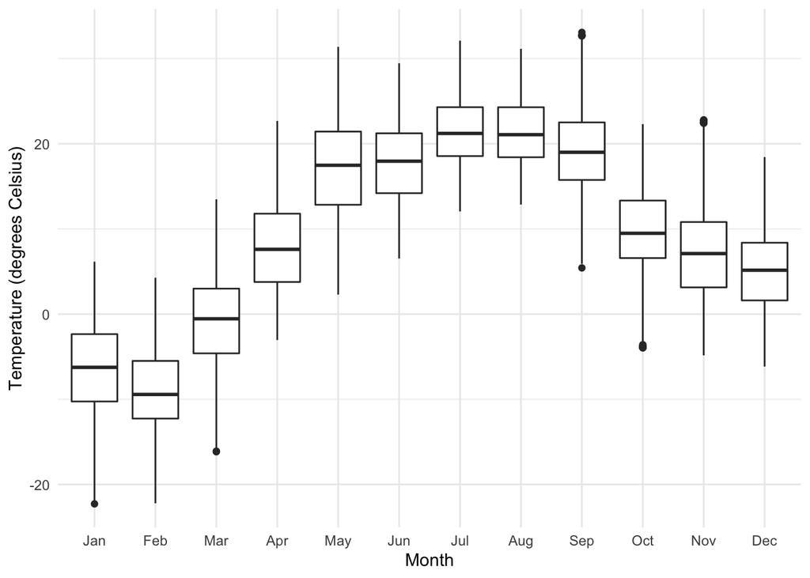

```r
ggplot(
  data = whately_2015,
  aes(
    x = lubridate::month(when, label = TRUE),
    y = temperature
  )
) +
  geom_boxplot() +
  xlab("Month") +
  ylab("Temperature (degrees Celsius)")
```